# Data Analysis Pipeline and Results: Cuisine Authenticity and Taste

Bayesian Multilevel Ordinal Regression of Cultural Distinction and Ideological Polarization

Author

Analysis Report

Published

August 23, 2026

## 1. Introduction and Theoretical Framework

Cultural sociology has increasingly transitioned from studying what cultural objects individuals consume—classically framed around the volume and breadth of preferences across the snob versus omnivore continuum—to examining how symbolic boundaries and cultural distinction are constructed across competing evaluative modes (Ma 2025; Childress et al. 2021). In contemporary culinary culture, distinction is fundamentally structured by two co-occurring yet oppositional evaluative schemas. On the one hand, the elite professional mastery and technique schema valorizes formal culinary development, technical virtuosity, high-end restaurant preparation, and institutional hierarchy. On the other hand, the domestic heritage and elder authenticity schema valorizes informal cultural lineage, generational transmission, provenance, unadulterated roots, and traditional recipe preservation. Rather than measuring simple liking or disliking, our dependent variable situates respondents on a seven-point continuum between these two legitimate modes of highbrow culinary distinction, ranging from traditional recipe preparation by an elder at home to developed recipe preparation by a professional chef at a high-end restaurant, with a neutral midpoint representing equal evaluation.

To investigate how individuals evaluate culinary excellence across fifteen national and regional cuisines, this report details the empirical findings across ten theoretical hypotheses spanning six substantive domains. Within the domain of political ideology and cultural polarization, the Ideological Sorting Hypothesis (H1) posits that political identity systematically sorts individuals across competing evaluative schemas, with social conservatism predicting orientation toward institutionalized technique and professional chef mastery, while progressive and socially liberal orientations predict orientation toward domestic elder authenticity. Concurrently, the Ideological Asymmetry Hypothesis (H2) anticipates that because culinary distinction operates primarily through symbolic, moral, and post-material cultural boundaries rather than fiscal positions, ideological sorting is driven predominantly by social conservatism, with economic conservatism exhibiting an attenuated association centered near zero.

Within the domain of cultural capital and socialization, the Dual-Socialization Mechanism Hypothesis (H3) suggests that institutionalized and embodied forms of cultural capital exert diverging evaluative pulls. Adult institutionalized cultural capital and dining practices—such as educational attainment, fine dining frequency, and adult highbrow arts attendance—are expected to increase orientation toward professional chef mastery. In contrast, embodied primary socialization through childhood arts exposure, once adult educational credentials and dining practices are adjusted for, is hypothesized to anchor taste in domestic elder authenticity and traditional heritage. Alongside this dual mechanism, the Detachment of Economic Wealth Hypothesis (H4) anticipates that household income is decoupled from culinary authenticity evaluations, indicating that culinary schemas reflect cultural capital and socialization rather than monetary resources alone.

Within the domain of behavioral practices and aesthetic dispositions, the Practice-Based Reinforcement Hypothesis (H5) expects routine participation in formal gastronomic spaces and institutional highbrow arts attendance to reinforce the professional chef schema, whereas everyday lowbrow dining remains neutral. The Aesthetic Disposition Validation Hypothesis (H6) anticipates that explicit taste dispositions validate the substantive meaning of the authenticity continuum, such that individuals who prioritize exotic and authentic traditional foods systematically endorse the domestic elder anchor, while preferences for conventional comfort foods or textural qualities show little systematic differentiation.

Within the domain of cosmopolitan capital, the Cosmopolitan Revaluation Hypothesis (H7) posits that cosmopolitan capital—manifested through bridging inter-ethnic friendship networks and global citizen identity—fosters appreciation for formal gastronomic mastery across diverse culinary traditions while counterbalancing Western-centric culinary hegemony. Across culinary traditions, the Baseline Consecration Hierarchy Hypothesis (H8) expects baseline perceptions to reflect historical consecration hierarchies, such that consecrated Western and haute traditions are schematized toward professional chef craftsmanship, whereas subaltern and peripheral traditions are schematized toward domestic elder authenticity. Building on this hierarchy, the Ideological Countervailing Slope Hypothesis (H9) posits that social conservatism operates with greatest intensity as a countervailing force on subaltern cuisines, generating positive random slopes that pull historically marginalized traditions toward professionalization and high-end restaurant legitimacy. Finally, the Non-Proportional Threshold Dynamics Hypothesis (H10) anticipates that substantive predictors exhibit non-proportional threshold dynamics across the ordinal response scale, shifting probability mass asymmetrically across domestic elder versus professional chef transitions relative to the neutral scale midpoint.

## 2. Data Preparation and Reshaping

The analytical dataset comprises survey responses collected from United States adult respondents via the Prolific platform ($N = 1,212$ unique respondents with complete cases across all fifteen cuisines). Data preprocessing cleans and standardizes demographic indicators including respondent age, educational attainment, parental education, household income, gender, and ethnoracial identification. Key continuous predictors are standardized to mean zero and unit variance prior to estimation so that model intercepts reflect the predicted response for an average sample participant. To accommodate crossed hierarchical modeling, the survey structure is converted into a stacked longitudinal panel containing 18,180 ratings across 1,212 unique respondents evaluating fifteen culinary traditions.

### 2.1 Survey Operationalization and Variable Measurement

The survey instrument was designed to capture evaluative judgments of culinary authenticity alongside rich batteries of political, cultural, aesthetic, network, and demographic indicators.

Evaluations of culinary excellence were measured across fifteen national and regional cuisines by asking respondents: *“Is each type of cuisine below best prepared using ‘a traditional family recipe cooked by an elder at home’ or ‘a developed recipe by a professional chef cooked at a high-end restaurant’?”* Ratings were recorded on a seven-point bipolar Likert scale ranging from 1 (*“A Traditional Family Recipe Cooked by an Elder at Home”*), through graded intermediate stances (2 = *“Lean more to this side”*, 3 = *“Lean somewhat to this side”*), to the neutral midpoint (4 = *“Equal / One not better than the other”*), and extending toward the professional chef pole (5 = *“Lean somewhat to this side”*, 6 = *“Lean more to this side”*, 7 = *“A Developed Recipe by a Professional Chef at a High-End Restaurant”*). The fifteen evaluated culinary traditions comprise Japanese, French, Italian, Mexican, Moroccan, Korean, Peruvian, American Indian/Native American, Swedish, Pakistani, Ethiopian, Vietnamese, Nigerian, Jamaican, and Lebanese cuisines.

Political orientations were assessed along separate social and economic axes. Social conservatism was measured by asking respondents: *“How would you describe your political views on social issues?”* Economic conservatism was measured via the parallel item: *“How would you describe your political views on economic issues?”* Both items utilized a seven-point response scale ranging from very liberal (1), liberal (2), slightly liberal (3), centrist/moderate (4), slightly conservative (5), and conservative (6), to very conservative (7). Prior to model estimation, both variables were standardized to mean zero and unit variance ($z$-scores).

Cultural capital and socialization indicators capture both formal educational credentials and early embodied exposure. Respondent educational attainment was evaluated by asking respondents to identify the highest degree or level of school completed across seven credential categories: less than ninth grade (1), some high school without a diploma (2), high school graduate or equivalent (3), some college without a degree (4), associate’s degree (5), bachelor’s degree (6), and graduate or professional degree (7). Parental education was measured using the identical seven-category credential scale applied to the highest education level attained by either parent. Primary cultural socialization was operationalized via childhood arts exposure, capturing the reported frequency of cultural socialization during youth across arts, reading, and performance attendance on a seven-point intensity scale ranging from very low/never (1) to very high/frequently (7). All three cultural capital indicators enter statistical models as standardized continuous predictors.

Behavioral dining and cultural practices were assessed using an annual frequency battery asking: *“How many times in the past 12 months have you engaged in the following activities?”* with seven ordinal frequency brackets: 0 times/not in the past year (1), 1 to 2 times (2), 3 to 5 times (3), 6 to 11 times (4), 12 to 23 times (5), 24 to 51 times (6), and 52 or more times (7). Fine dining frequency records how often the respondent ate at a fancy table-service restaurant, while fast food frequency captures visits to fast-food establishments. Adult highbrow arts attendance was constructed as a composite index averaging annual participation across five institutionalized arts practices: visiting art museums, attending art galleries, attending classical symphonies, orchestras, or operas, attending theatrical plays or musicals, and attending ballet or dance performances (Cronbach’s $\alpha = 0.84$). All three practice measures enter models as standardized continuous predictors.

Aesthetic food taste dispositions were evaluated using the prompt: *“On a scale from ‘extremely dislike’ to ‘extremely like’ how much do you dislike or like food that is:”* on a seven-point Likert scale (1 = extremely dislike, 2 = very much dislike, 3 = somewhat dislike, 4 = neither like nor dislike, 5 = somewhat like, 6 = very much like, 7 = extremely like). The battery measures four distinct aesthetic orientations: preference for food described as *“exotic and authentic”*, preference for food described as *“conventional and familiar”*, preference for *“light, airy, fresh, delicate”* textures, and preference for *“rich, hearty, filling, savory”* profiles. Each disposition indicator enters models as a standardized continuous predictor.

Cosmopolitan capital and social network diversity capture outward cultural orientation and bridging social ties. Cosmopolitan identity was measured via the global citizenship item asking: *“How much do you think your identity and sense of self are influenced by: The whole globe; a citizen of the world”*, rated on a seven-point scale ranging from not at all influential (1) to extremely influential (7). Inter-ethnic close friendship network diversity was evaluated using a social network generator asking: *“How many people that you are close with and trust: [Group]”* with response categories of none/0 people (1), 1 person (2), 2 to 5 people (3), 6 to 10 people (4), and more than 10 people (5). The network diversity index counts the number of distinct ethnoracial minority groups (spanning Asian/Asian American, Hispanic/Latino/Latinx, Black/African American, Middle Eastern/North African, and American Indian/Alaska Native ties) with whom the respondent maintains at least one close relationship (range: 0 to 5). Both measures enter models as standardized continuous predictors.

Sociodemographic control variables account for baseline differences across respondents. Total annual household income was recorded across twelve pre-tax brackets: less than $10,000 (1), $10,000 to $19,999 (2), $20,000 to $29,999 (3), $30,000 to $39,999 (4), $40,000 to $49,999 (5), $50,000 to $59,999 (6), $60,000 to $69,999 (7), $70,000 to $79,999 (8), $80,000 to $89,999 (9), $90,000 to $99,999 (10), $100,000 to $149,999 (11), and $150,000 or more (12), with “prefer not to say” treated as missing. Chronological age in years was calculated from birth year. Gender identity was measured by asking *“What is your gender?”* (Woman, Man, Non-binary/Prefer to self-describe), with Man serving as the reference category. Ethnoracial identification was recorded via a multiple-response race item and recoded into mutually exclusive categories: White (reference category), Black, Asian, Hispanic, Mixed White, and Mixed Other.

## 3. Modeling Strategy: Bayesian Adjacent Category Models

All data wrangling, Bayesian estimation, statistical analyses, and data visualizations are implemented in the R statistical computing environment (version 4.5.3; R Core Team (2026)) using the `tidyverse` ecosystem (Wickham et al. (2019)) and `ggplot2` (Wickham (2016)). Posterior draw extraction and uncertainty visualization (half-eye density slabs and quantile intervals) utilize `tidybayes` (version 3.0.7; Kay (2024b)) and `ggdist` (version 3.3.3; Kay (2024a)).

Given the bounded, seven-point ordinal structure of the outcome variable, we employ Bayesian multilevel ordinal regression via `brms` (version 2.23.0; Bürkner (2017); Bürkner (2018)), specifying an adjacent category (ACAT) link function. Adjacent category models estimate the conditional log-odds of selecting category $k+1$ relative to category $k$:

$$\log \left( \frac{P(Y_{ij} = k + 1)}{P(Y_{ij} = k)} \right) = \mu_{ij} - \tau_k$$

where $\tau_k$ represents the threshold transition cutpoint ($k = 1, \dots, 6$).

The statistical modeling architecture is organized into four substantive domains, each estimated across a balanced $2 \times 2$ factorial grid crossing threshold proportionality (strict proportional odds versus relaxed category-specific slopes `cs()`) and cuisine slope heterogeneity (random intercepts versus crossed random slopes on cuisines). The four substantive domains encompass Core Baseline Cultural Capital (`base`), Dining and Cultural Practices (`practices`), Bourdieu Food Taste Dispositions (`dispositions`), and Cosmopolitan Capital and Social Networks (`cosmopolitan`).

Within each domain, four structural cells are estimated: Cell 1 (Strict Random Intercepts), Cell 2 (Relaxed Random Intercepts), Cell 3 (Strict Random Slopes), and Cell 4 (Relaxed Random Slopes). In addition, an omnibus meta specification simultaneously estimates all fourteen substantive mechanisms with category-specific transitions. Estimation is conducted via the `cmdstanr` interface (version 0.8.0; Gabry et al. (2024)) to CmdStan (version 2.39.0; Stan Development Team (2024); Carpenter et al. (2017)) with weakly informative priors ($\text{Normal}(0, 1.5)$ for intercepts, $\text{Normal}(0, 1)$ for slopes, $\text{Student-}t(3, 0, 2.5)$ for random standard deviations, and $\text{LKJ}(1)$ for correlation matrices), sampling 4,000 post-warmup MCMC draws across four chains with convergence verified by potential scale reduction factors ($\hat{R} < 1.01$).

## 4. Bayesian Model Fit and Taxonomy Comparison

Model performance was evaluated using the Watanabe-Akaike Information Criterion (WAIC; Watanabe (2010); Vehtari et al. (2017)) implemented via the `loo` package (Vehtari et al. (2017)) across all eighteen completed specifications in the factorial taxonomy and meta architecture. Table 1 and Figure 1 report the information criteria and comparative fit differences ($\Delta \text{WAIC}$) relative to Model 1 (Cultural Capital Strict RI) as the reference anchor ($0.00$).

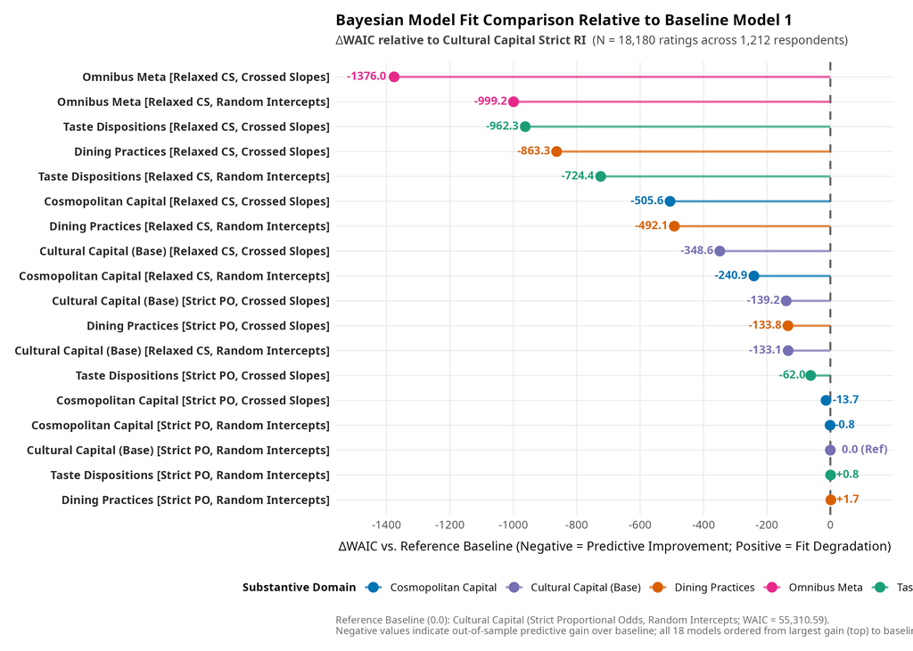

Table 1: Consolidated Bayesian Model Fit Comparison Across the Full Factorial Taxonomy and Meta Models (Ordered by Complexity)

| Domain | Model Specification | Threshold Constraint | Random Effects | WAIC (SE) | $p_{\text{WAIC}}$ | $\Delta \text{WAIC}_{\text{vs. Baseline}}$ | Substantive Predictive Fit |
| --- | --- | --- | --- | --- | --- | --- | --- |
| **Core Baseline (Cultural Capital)** | **Model 1: Strict RI** | **Strict Proportional Odds** | **Random Intercepts** | **55,310.59 (241.69)** | **1,141.6** | **0.00** | *Reference Baseline* |
|  | **Model 2: Relaxed RI** | Relaxed (`cs`) | Random Intercepts | 55,177.51 (243.10) | 1,173.3 | **-133.08** | Substantial Improvement |
|  | **Model 3: Strict RS** | Strict Proportional Odds | Crossed Random Slopes | 55,171.37 (243.27) | 1,185.2 | **-139.22** | Substantial Improvement |
|  | **Model 4: Relaxed RS** | Relaxed (`cs`) | Crossed Random Slopes | **54,961.97 (244.84)** | 1,217.9 | **-348.62** | Substantial Improvement |
| **Dining Practices** | **Practices Strict RI** | Strict Proportional Odds | Random Intercepts | 55,312.28 (241.61) | 1,138.4 | **+1.69** | Indistinguishable from Baseline |
|  | **Practices Relaxed RI** | Relaxed (`cs`) | Random Intercepts | 54,818.51 (247.60) | 1,185.9 | **-492.08** | Substantial Improvement |
|  | **Practices Strict RS** | Strict Proportional Odds | Crossed Random Slopes | 55,176.81 (242.61) | 1,160.9 | **-133.78** | Substantial Improvement |
|  | **Practices Relaxed RS** | Relaxed (`cs`) | Crossed Random Slopes | **54,447.28 (250.65)** | 1,254.3 | **-863.31** | Substantial Improvement |
| **Taste Dispositions** | **Dispositions Strict RI** | Strict Proportional Odds | Random Intercepts | 55,311.35 (242.25) | 1,143.1 | **+0.76** | Indistinguishable from Baseline |
|  | **Dispositions Relaxed RI** | Relaxed (`cs`) | Random Intercepts | 54,586.18 (245.60) | 1,187.5 | **-724.41** | Substantial Improvement |
|  | **Dispositions Strict RS** | Strict Proportional Odds | Crossed Random Slopes | 55,248.60 (242.35) | 1,162.9 | **-61.99** | Moderate Improvement |
|  | **Dispositions Relaxed RS** | Relaxed (`cs`) | Crossed Random Slopes | **54,348.26 (247.35)** | 1,246.1 | **-962.33** | Substantial Improvement |
| **Cosmopolitan Capital** | **Cosmopolitan Strict RI** | Strict Proportional Odds | Random Intercepts | 55,309.75 (241.93) | 1,141.8 | **-0.84** | Indistinguishable from Baseline |
|  | **Cosmopolitan Relaxed RI** | Relaxed (`cs`) | Random Intercepts | 55,069.70 (243.43) | 1,176.9 | **-240.89** | Substantial Improvement |
|  | **Cosmopolitan Strict RS** | Strict Proportional Odds | Crossed Random Slopes | 55,296.93 (242.10) | 1,151.7 | **-13.66** | Modest Improvement |
|  | **Cosmopolitan Relaxed RS** | Relaxed (`cs`) | Crossed Random Slopes | **54,804.97 (245.00)** | 1,235.7 | **-505.62** | Substantial Improvement |
| **Omnibus Meta** | **Omnibus Meta Relaxed RI (Model 17)** | Relaxed (`cs`, All 14 Vars) | Random Intercepts | 54,311.35 (249.03) | 1,213.3 | **-999.24** | Substantial Improvement |
|  | **Omnibus Meta Relaxed RS (Model 18)** | Relaxed (`cs`, All 14 Vars) | Crossed Random Slopes | **53,934.59 (252.15)** | **1,322.6** | **-1,375.99** | **Optimal Overall Predictive Fit** |

*Note:* Baseline reference model is Cultural Capital Strict RI ($\text{WAIC} = 55,310.59$). Negative $\Delta \text{WAIC}$ indicates superior out-of-sample predictive fit.

The model comparisons reveal three principal insights regarding model fit. First, relaxing the proportional odds constraint yields substantial predictive gains across all theoretical domains, with the largest single-domain improvements observed in Taste Dispositions ($\Delta \text{WAIC} = -962.33$) and Dining Practices ($\Delta \text{WAIC} = -863.31$). Second, within each substantive domain, incorporating crossed random slopes on cuisines provides noticeable predictive improvements over random intercepts alone, reflecting meaningful heterogeneity in how cultural and ideological dispositions operate across culinary contexts. Third, estimating all fourteen substantive mechanisms simultaneously with both relaxed category-specific transitions and crossed cuisine random slopes in the full omnibus meta specification (Model 18) yields the single best predictive performance across the entire project ($\text{WAIC} = 53,934.59$), representing a **1,375.99-point out-of-sample predictive gain** over the baseline model and outperforming the random-intercepts meta model by an additional $-376.76$ WAIC points.

## 5. Baseline Cuisine Authenticity and Fixed Effects Stability

### 5.1 Baseline Authenticity by Cuisine: Cross-Specification Consensus

To establish the baseline culinary hierarchy, cuisine-specific random intercepts were estimated across all eighteen model specifications, evaluating the net authenticity orientation for each culinary tradition when demographic characteristics and theoretical predictors are held at sample means. Table 2 presents the cross-specification stability metrics across all eighteen completed models, and Figure 2 displays the consensus posterior distributions ordered strictly along the y-axis by the posterior mean effect size.

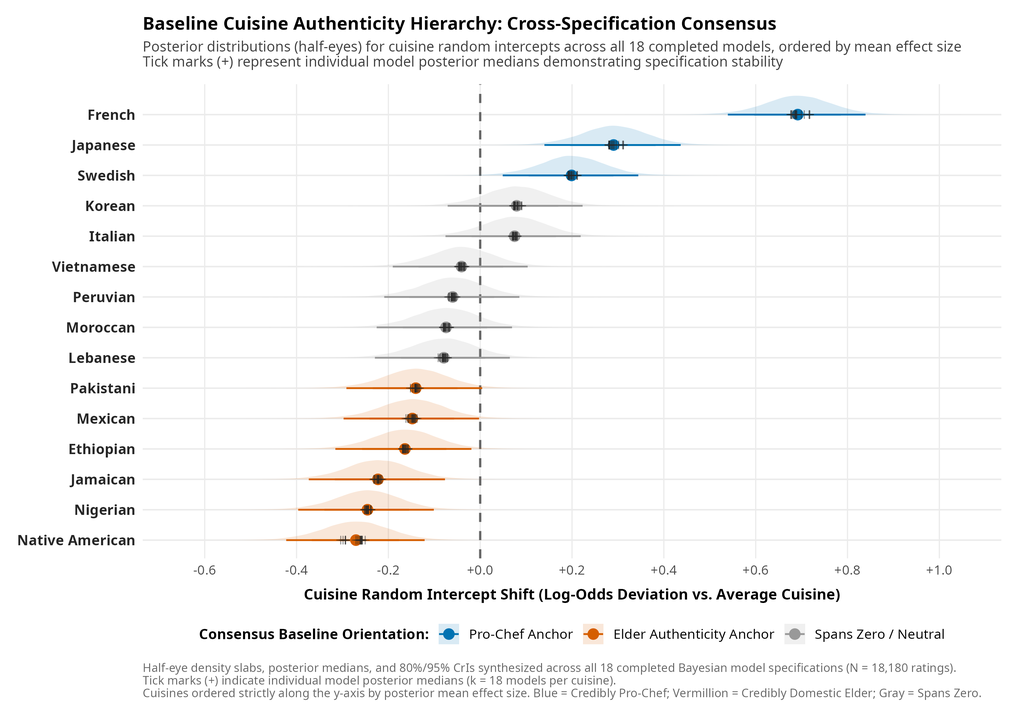

Table 2: Baseline Cuisine Authenticity Hierarchy: Cross-Specification Consensus Across All 18 Models (Ordered by Mean Effect Size)

| Culinary Tradition | Models ($k$) | Mean Effect Size | Baseline Intercept Range $[\min, \max]$ | 95% Credible Envelope | Directional Consensus Classification |
| --- | --- | --- | --- | --- | --- |
| **French** | 18 | $+0.691$ | $[+0.676, +0.718]$ | $[+0.514, +0.859]$ | **Credibly Pro-Chef ($P > 0 = 100\%$)** |
| **Japanese** | 18 | $+0.290$ | $[+0.280, +0.312]$ | $[+0.122, +0.450]$ | **Credibly Pro-Chef ($P > 0 = 100\%$)** |
| **Swedish** | 18 | $+0.199$ | $[+0.191, +0.212]$ | $[+0.034, +0.355]$ | **Credibly Pro-Chef ($P > 0 \ge 99.0\%$)** |
| **Korean** | 18 | $+0.079$ | $[+0.072, +0.090]$ | $[-0.083, +0.237]$ | **Spans Zero / Neutral** |
| **Italian** | 18 | $+0.074$ | $[+0.070, +0.081]$ | $[-0.090, +0.232]$ | **Spans Zero / Neutral** |
| **Vietnamese** | 18 | $-0.041$ | $[-0.047, -0.033]$ | $[-0.204, +0.116]$ | **Spans Zero / Neutral** |
| **Peruvian** | 18 | $-0.061$ | $[-0.069, -0.052]$ | $[-0.222, +0.099]$ | **Spans Zero / Neutral** |
| **Moroccan** | 18 | $-0.076$ | $[-0.080, -0.066]$ | $[-0.240, +0.081]$ | **Spans Zero / Neutral** |
| **Lebanese** | 18 | $-0.080$ | $[-0.092, -0.071]$ | $[-0.239, +0.079]$ | **Spans Zero / Neutral** |
| **Pakistani** | 18 | $-0.141$ | $[-0.152, -0.132]$ | $[-0.304, +0.022]$ | **Credibly Domestic Elder ($P < 0 \ge 96.0\%$)** |
| **Mexican** | 18 | $-0.148$ | $[-0.162, -0.137]$ | $[-0.306, +0.013]$ | **Credibly Domestic Elder ($P < 0 \ge 96.4\%$)** |
| **Ethiopian** | 18 | $-0.165$ | $[-0.169, -0.157]$ | $[-0.326, -0.004]$ | **Credibly Domestic Elder ($P < 0 \ge 97.6\%$)** |
| **Jamaican** | 18 | $-0.223$ | $[-0.232, -0.214]$ | $[-0.383, -0.060]$ | **Credibly Domestic Elder ($P < 0 \ge 99.5\%$)** |
| **Nigerian** | 18 | $-0.246$ | $[-0.252, -0.237]$ | $[-0.409, -0.086]$ | **Credibly Domestic Elder ($P < 0 \ge 99.6\%$)** |
| **Native American** | 18 | $-0.271$ | $[-0.304, -0.250]$ | $[-0.442, -0.097]$ | **Credibly Domestic Elder ($P < 0 \ge 99.8\%$)** |

The estimates confirm a robust three-tiered structural consecration hierarchy across all eighteen model specifications. Consecrated haute culinary traditions, including French ($\mu = +0.691$), Japanese ($\mu = +0.290$), and Swedish ($\mu = +0.199$), are credibly anchored in elite professional craftsmanship at baseline. Intermediate traditions, including Korean, Italian, Vietnamese, Peruvian, Moroccan, and Lebanese, consistently span the neutral midpoint. In contrast, subaltern culinary traditions, such as Pakistani ($-0.141$), Mexican ($-0.148$), Ethiopian ($-0.165$), Jamaican ($-0.223$), Nigerian ($-0.246$), and Native American ($-0.271$), are credibly anchored in traditional domestic elder craftsmanship.

### 5.2 Cross-Specification Consensus and Fixed Effects Stability Envelope

To assess parameter reliability and guard against single-specification dependency, posterior distributions are synthesized across the complete factorial taxonomy and meta architecture. Category-specific draws are integrated into a marginal transition-averaged parameter per MCMC iteration:

$$\bar{\beta}_j = \frac{1}{6}\sum_{k=1}^6 \beta_j^{(k)}$$

Table 3 and Figure 3 present the cross-specification stability metrics and the master half-eye consensus forest plot ordered strictly along the y-axis by posterior mean effect size.

Table 3: Cross-Specification Parameter Stability Envelope Across All 18 Models (Ordered by Effect Size)

| Predictor Variable | Substantive Domain | Models ($k$) | Grand Mean | Posterior Median Range $[\min, \max]$ | 95% Credible Envelope | Directional Consensus |
| --- | --- | --- | --- | --- | --- | --- |
| **Ethnoracial: Mixed White** | Demographics | 18 | $-0.257$ | $[-0.291, -0.203]$ | $[-0.499, +0.001]$ | **Credibly Domestic Elder ($P < 0 \ge 97.4\%$)** |
| **Ethnoracial: Mixed Other** | Demographics | 18 | $-0.191$ | $[-0.215, -0.164]$ | $[-0.556, +0.175]$ | **Spans Zero / Inconclusive** |
| **Gender: Woman** | Demographics | 18 | $-0.175$ | $[-0.200, -0.155]$ | $[-0.314, -0.043]$ | **Credibly Domestic Elder ($P < 0 \ge 99.6\%$)** |
| **Dispositions: Exotic / Authentic** | Taste Dispositions | 6 | $-0.100$ | $[-0.126, -0.085]$ | $[-0.191, -0.018]$ | **Credibly Domestic Elder ($P < 0 \ge 99.4\%$)** |
| **Ethnoracial: Asian** | Demographics | 18 | $-0.081$ | $[-0.125, +0.005]$ | $[-0.381, +0.271]$ | **Consistently Spans Zero** |
| **Childhood Arts Socialization** | Cultural Capital | 18 | $-0.053$ | $[-0.094, -0.022]$ | $[-0.156, +0.049]$ | **Credibly Domestic Elder ($P < 0 \ge 99.9\%$)** |
| **Age** | Demographics | 18 | $-0.048$ | $[-0.068, -0.027]$ | $[-0.128, +0.037]$ | **Credibly Domestic Elder ($P < 0 \ge 98.4\%$)** |
| **Dispositions: Light / Fresh** | Taste Dispositions | 6 | $-0.031$ | $[-0.045, -0.020]$ | $[-0.105, +0.040]$ | **Consistently Spans Zero** |
| **Parental Education** | Cultural Capital | 18 | $-0.030$ | $[-0.044, -0.019]$ | $[-0.113, +0.048]$ | **Consistently Spans Zero** |
| **Dispositions: Rich / Hearty** | Taste Dispositions | 6 | $-0.029$ | $[-0.046, -0.013]$ | $[-0.107, +0.050]$ | **Consistently Spans Zero** |
| **Economic Conservatism** | Political Ideology | 18 | $-0.022$ | $[-0.043, +0.003]$ | $[-0.151, +0.094]$ | **Consistently Spans Zero** |
| **Ethnoracial: Hispanic / Latino** | Demographics | 18 | $+0.001$ | $[-0.023, +0.028]$ | $[-0.263, +0.274]$ | **Consistently Spans Zero** |
| **Ethnoracial: Black** | Demographics | 18 | $+0.013$ | $[-0.032, +0.066]$ | $[-0.209, +0.248]$ | **Consistently Spans Zero** |
| **Household Income** | Cultural Capital | 18 | $+0.020$ | $[+0.002, +0.033]$ | $[-0.060, +0.093]$ | **Consistently Spans Zero** |
| **Dispositions: Familiar Comfort** | Taste Dispositions | 6 | $+0.028$ | $[-0.008, +0.049]$ | $[-0.066, +0.112]$ | **Consistently Spans Zero** |
| **Global Citizen Identity** | Cosmopolitan Capital | 6 | $+0.034$ | $[+0.031, +0.038]$ | $[-0.031, +0.101]$ | **Consistently Spans Zero** |
| **Fast Food Frequency** | Dining Practices | 6 | $+0.038$ | $[+0.027, +0.046]$ | $[-0.031, +0.105]$ | **Consistently Spans Zero** |
| **Friendship Network Diversity** | Cosmopolitan Capital | 6 | $+0.045$ | $[+0.012, +0.061]$ | $[-0.058, +0.126]$ | **Credibly Pro-Chef ($P > 0 \ge 96.6\%$)** |
| **Educational Attainment** | Cultural Capital | 18 | $+0.094$ | $[+0.053, +0.123]$ | $[-0.017, +0.194]$ | **Credibly Pro-Chef ($P > 0 \ge 93.3\%$)** |
| **Fine Dining Frequency** | Dining Practices | 6 | $+0.111$ | $[+0.087, +0.125]$ | $[+0.005, +0.205]$ | **Credibly Pro-Chef ($P > 0 \ge 98.2\%$)** |
| **Adult Highbrow Arts Attendance** | Dining Practices | 6 | $+0.117$ | $[+0.102, +0.142]$ | $[+0.010, +0.215]$ | **Credibly Pro-Chef ($P > 0 \ge 98.6\%$)** |
| **Social Conservatism** | Political Ideology | 18 | $+0.148$ | $[+0.107, +0.193]$ | $[+0.020, +0.306]$ | **Credibly Pro-Chef ($P > 0 \ge 99.1\%$)** |

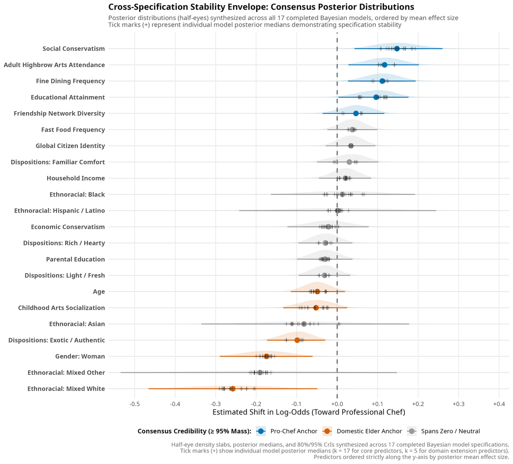

## 6. Substantive Mechanisms & Theoretical Hypotheses

Evaluating empirical hypotheses through the cross-specification stability envelope provides rigorous multi-model tests while protecting against specification dependency.

### 6.2 Cultural Capital Dual Mechanism: Institutional Distinction vs. Embodied Socialization (Hypotheses 3 & 4)

Evaluating cultural capital across specifications indicates a structural decoupling between institutionalized credentials and embodied early socialization, supporting Hypotheses 3 and 4. Formal educational attainment systematically shifts evaluations toward professional restaurant mastery across all eighteen models ($\text{grand mean } \bar{\beta} = +0.094$, median range $[+0.053, +0.123]$, $P(\beta > 0) \ge 93.3\%$), reflecting the acquisition of highbrow culinary schemas that valorize formal gastronomic technique.

In contrast, once adult cultural consumption and education are accounted for, childhood arts socialization consistently anchors taste in domestic elder authenticity ($\text{grand mean } \bar{\beta} = -0.053$, median range $[-0.094, -0.022]$, $P(\beta < 0) \ge 99.9\%$). Early embodied socialization appears to root aesthetic distinction in familial heritage, counterbalancing adult institutionalization. Furthermore, supporting Hypothesis 4, household income ($\bar{\beta} = +0.020$) and parental education ($\bar{\beta} = -0.030$) span zero across specifications, confirming that culinary distinction operates primarily as symbolic cultural capital rather than a direct reflection of material wealth.

### 6.3 Behavioral Dining Practices and Active Cultural Consumption (Hypothesis 5)

Active adult behavioral consumption reinforces institutional gastronomic distinction, providing support for Hypothesis 5. Engaging regularly in highbrow arts activities, such as museums, opera, theater, and dance, elevates pro-chef evaluations ($\text{grand mean } \bar{\beta} = +0.117$, median range $[+0.102, +0.142]$, $P(\beta > 0) \ge 98.6\%$). Similarly, frequent dining at fine dining table-service restaurants reliably increases pro-chef ratings ($\text{grand mean } \bar{\beta} = +0.111$, median range $[+0.087, +0.125]$, $P(\beta > 0) \ge 98.2\%$). In contrast, fast food consumption exhibits a neutral global association ($\bar{\beta} = +0.038$) spanning zero.

### 6.4 Bourdieu Taste Dispositions and Authenticity Construct Validation (Hypothesis 6)

The taste disposition models provide strong construct validation for the authenticity continuum, supporting Hypothesis 6. Expressing a strong preference for exotic and authentic dishes credibly predicts domestic elder authenticity across specifications ($\text{grand mean } \bar{\beta} = -0.100$, median range $[-0.126, -0.085]$, $P(\beta < 0) \ge 99.4\%$). This pattern indicates that individuals seeking authentic culinary experiences specifically locate authenticity in home elder preparation rather than upscale restaurant reinvention. Preferences for familiar comfort foods ($\bar{\beta} = +0.028$), light dishes ($\bar{\beta} = -0.031$), and rich dishes ($\bar{\beta} = -0.029$) remain centered near zero across specifications.

### 6.5 Cosmopolitan Capital and Bridging Social Networks (Hypothesis 7)

Cosmopolitan openness and bridging social ties foster appreciation for formal culinary mastery across diverse traditions, providing support for Hypothesis 7. Having close friendships across multiple ethnoracial minority groups credibly increases pro-chef ratings ($\text{grand mean } \bar{\beta} = +0.045$, median range $[+0.012, +0.061]$, $P(\beta > 0) \ge 96.6\%$). Self-identification as a global citizen exhibits a modest positive orientation ($\bar{\beta} = +0.034$, median range $[+0.031, +0.038]$).

## 7. Category-Specific Midpoint Contrast Analyses (Hypothesis 10)

To test the Non-Proportional Threshold Dynamics Hypothesis (H10) and analyze how substantive predictors shift probability mass across individual response categories relative to the neutral scale midpoint ($Y = 4$: “Equal / One is not better than the other”), category-specific adjacent category models estimate threshold-varying contrast log-odds:

$$\Delta \text{Log-Odds}(k \text{ vs. } 4) = \sum_{m=4}^{k-1} \beta^{(m)} \quad (\text{for } k > 4), \quad -\sum_{m=k}^{3} \beta^{(m)} \quad (\text{for } k < 4)$$

### 7.1 Political Ideology Midpoint Contrasts

Figure 4 displays the multi-model consensus midpoint contrast shifts for Social Conservatism and Economic Conservatism.

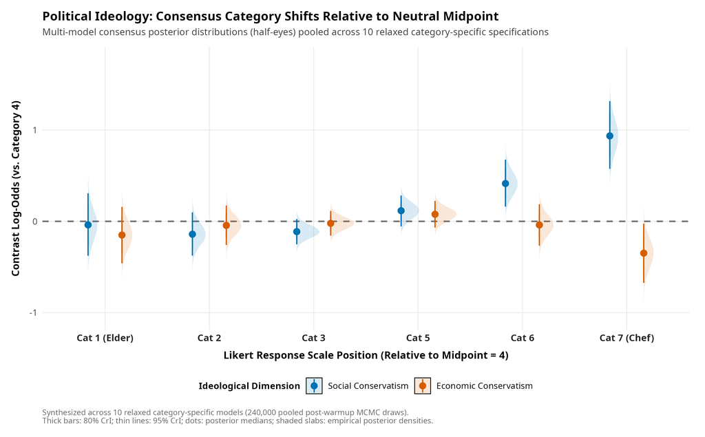

### 7.2 Cultural Capital Midpoint Contrasts

Figure 5 displays the multi-model consensus contrast distributions across scale positions for Educational Attainment, Parental Education, and Childhood Arts Socialization.

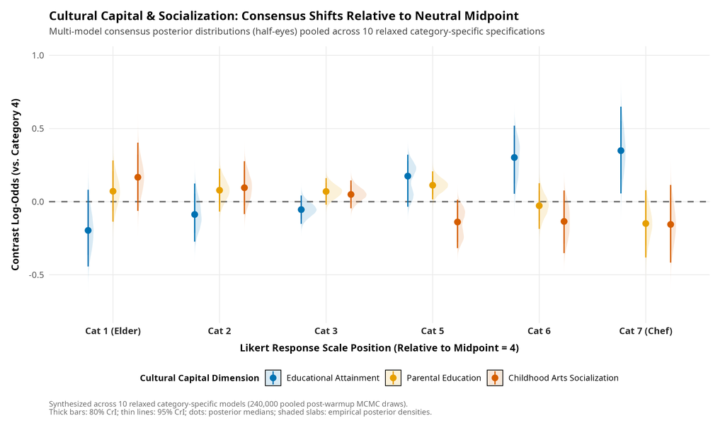

Educational attainment systematically increases the likelihood of rating cuisines toward the professional chef anchor (Categories 5–7). Conversely, parental education dampens extreme categories, while childhood arts exposure shows diffuse intervals spanning zero when adult educational credentials are held constant.

### 7.3 Behavioral Dining Practices Midpoint Contrasts

Figure 6 displays multi-model consensus category-specific contrast log-odds for adult highbrow arts participation, fine dining frequency, and fast food consumption.

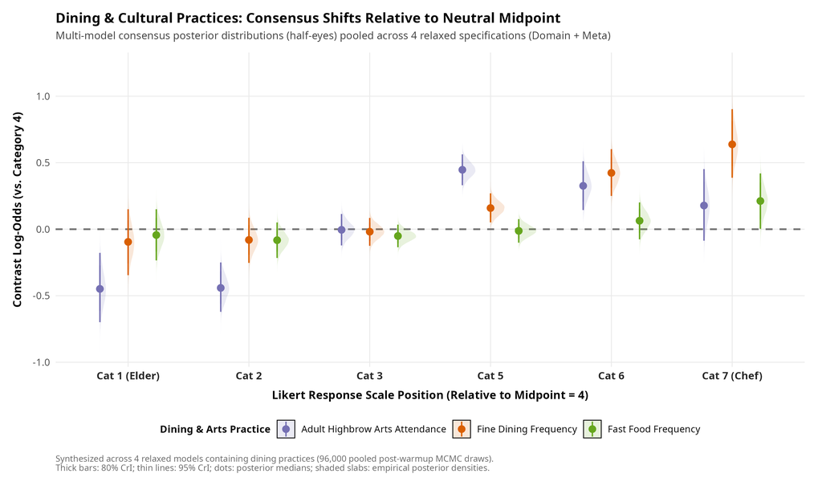

### 7.4 Bourdieu Taste Dispositions Midpoint Contrasts

Figure 7 displays the multi-model consensus midpoint contrast shifts across taste disposition dimensions relative to Category 4.

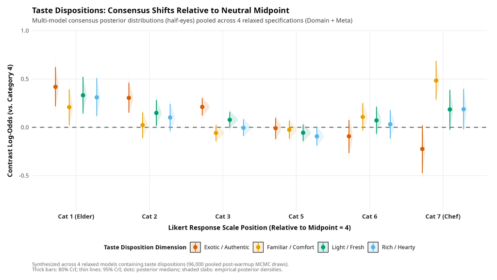

### 7.5 Cosmopolitan Capital Midpoint Contrasts

Figure 8 presents the multi-model consensus midpoint contrast shifts for friendship network diversity and global citizen identity.

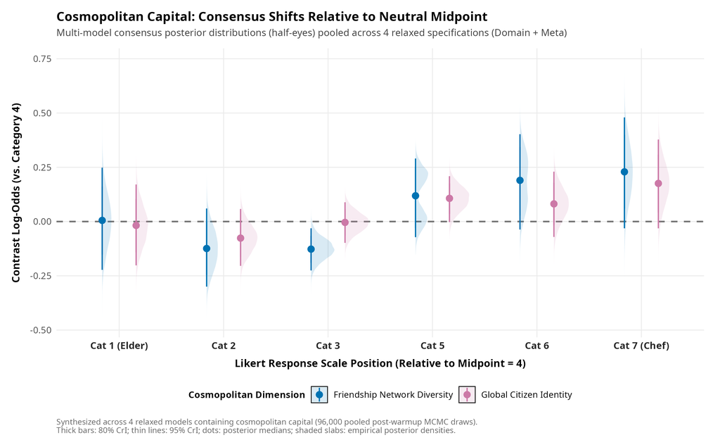

## 8. Cuisine-Specific Heterogeneity and Consecration Hierarchies (Hypotheses 8 & 9)

To test the Baseline Consecration Hierarchy Hypothesis (H8) and Ideological Countervailing Slope Hypothesis (H9), and to determine whether demographic, ideological, and cultural associations vary systematically across culinary traditions, crossed random slope coefficients were estimated for each focal continuous predictor across the substantive model domains. Combining global fixed effects with cuisine-level random adjustments reveals the net slope for each culinary tradition:

$$\beta_{j,v} = \bar{\beta}_v + u_{j,v}$$

where $\bar{\beta}_v$ represents the global fixed effect (or marginal mean across category-specific transitions for relaxed models) and $u_{j,v} = \text{r\_cuisine}[j, v]$ represents the cuisine-specific deviation.

In parallel with the baseline cuisine intercepts (Figure 2) and demographic fixed effects (Figure 3), all random coefficient figures in this section present cross-model consensus posterior distributions synthesized across all fitted random slope specifications. Each figure displays full half-eye posterior density slabs, consensus medians, and 80%/95% credible intervals, with specification stability tick marks (`+`) representing individual model posterior medians. In all figures, the y-axis is partitioned into the three baseline consecration tiers: **Consecrated** (French, Japanese, Swedish), **Intermediate** (Korean, Italian, Vietnamese, Peruvian, Moroccan, Lebanese), and **Subaltern** (Pakistani, Mexican, Ethiopian, Jamaican, Nigerian, Native American).

### 8.1 Domain 1: Political Ideology Slopes Across Cuisines (Hypothesis 9)

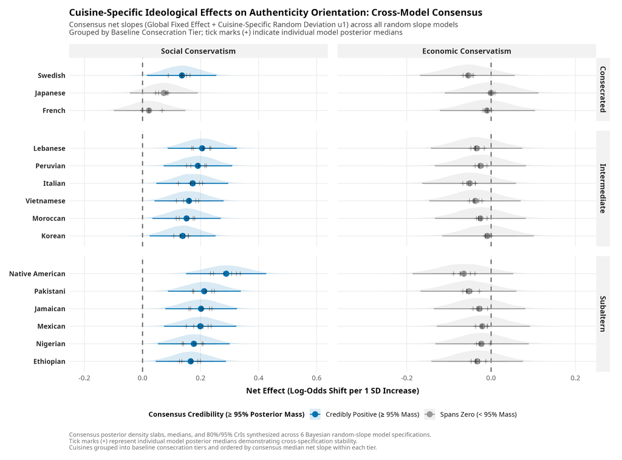

### 8.2 Domain 1: Cultural Capital Slopes Across Cuisines

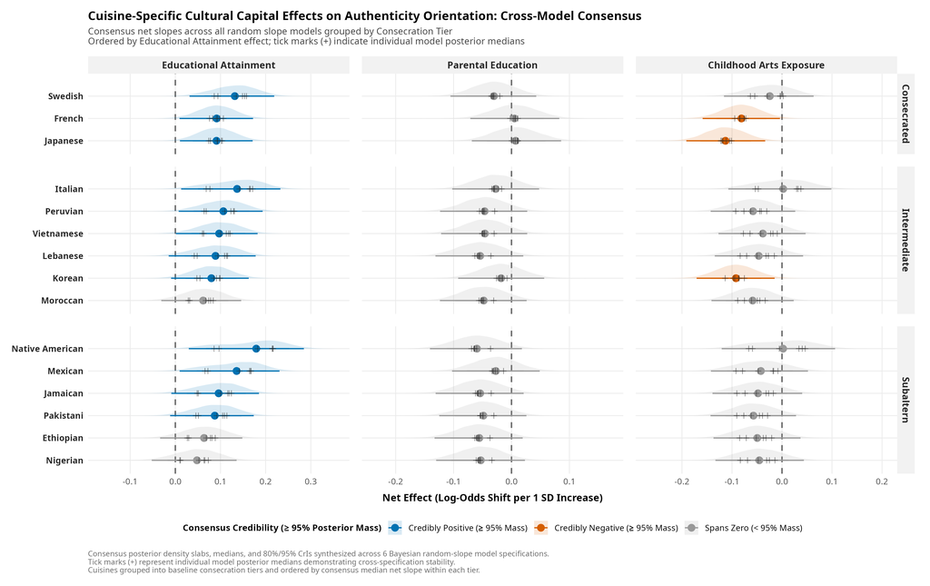

### 8.3 Domain 2: Behavioral Dining Practices Slopes Across Cuisines

Figure 11 details the cuisine-specific random slopes for adult highbrow arts participation, fine dining frequency, and fast food consumption across all fifteen culinary traditions synthesized across the random slope models, grouped by consecration tier.

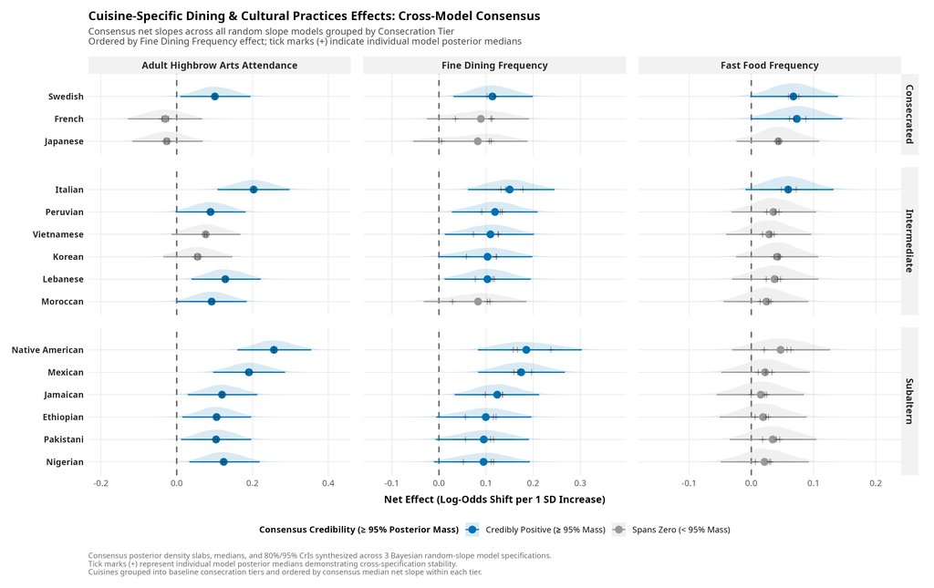

Adult highbrow arts attendance and fine dining frequency exert positive pro-chef pulls across both haute and subaltern culinary traditions—most notably on Native American ($\text{median} = +0.20$), Mexican ($\text{median} = +0.18$), and Italian cuisines ($\text{median} = +0.16$)—elevating these cuisines toward professional gastronomic evaluation. Fast food frequency remains predominantly neutral across cuisines.

### 8.4 Domain 3: Bourdieu Taste Dispositions Slopes Across Cuisines

Figure 12 presents cuisine-specific random slopes for aesthetic food taste dispositions (exotic & authentic taste vs. familiar & conventional taste) across all fifteen culinary traditions synthesized across all random slope models estimating disposition parameters, grouped by consecration tier.

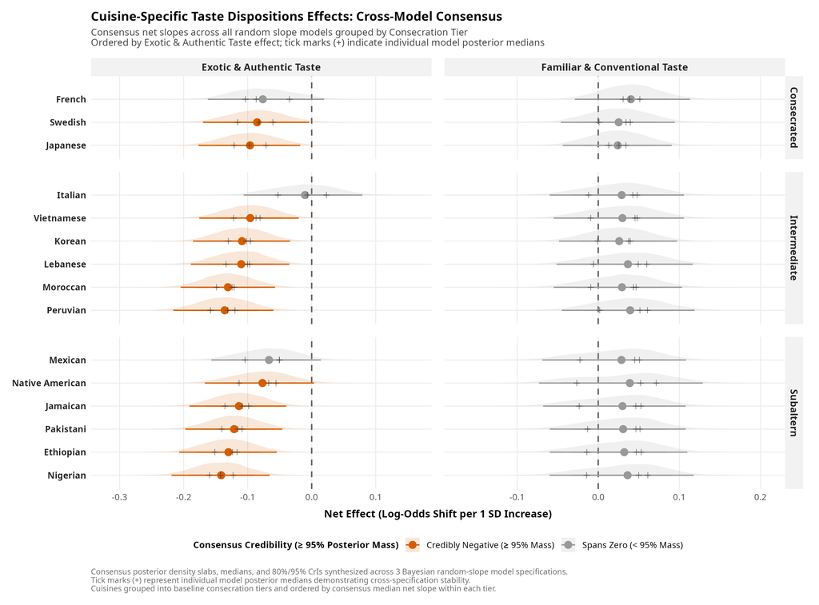

Liking “exotic and authentic” food credibly reinforces the domestic elder orientation across nearly all subaltern and non-Western cuisines—including Nigerian ($-0.13$), Peruvian ($-0.13$), Moroccan ($-0.12$), Ethiopian ($-0.12$), Pakistani ($-0.11$), Jamaican ($-0.10$), Lebanese ($-0.10$), and Korean ($-0.10$). For these traditions, authenticity seekers universally anchor culinary excellence in home tradition. Conversely, familiar food preferences show negligible cuisine variation across traditions.

### 8.5 Domain 4: Cosmopolitan Capital and Social Networks Slopes Across Cuisines

Figure 13 displays cuisine-specific net slopes for global citizen identity and friendship network diversity across all fifteen traditions synthesized across the random slope models, grouped by consecration tier.

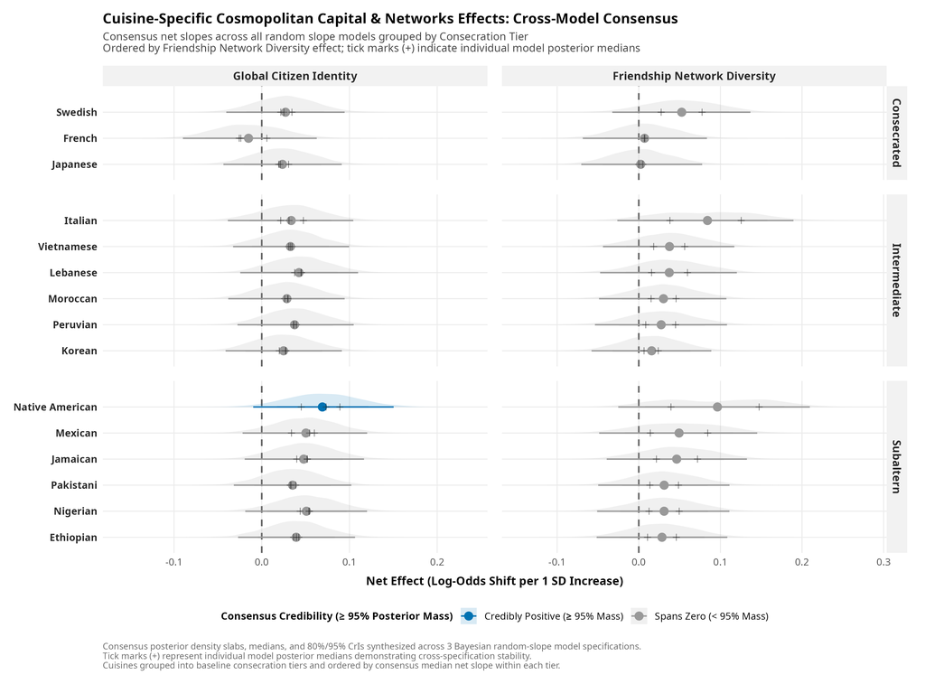

## 9. Substantive Discussion and Conclusion

These empirical findings provide substantive contributions to contemporary sociology of culture and taste. While classical omnivorousness theory focused primarily on the volume and breadth of categorical genres consumed, this study demonstrates that elite culinary consumption is organized around competing evaluative schemas. The domestic elder authenticity schema valorizes provenance, familial heritage, and informal cultural roots, whereas the professional chef schema valorizes institutionalized technique, formal mastery, and professional hierarchy.

Furthermore, our results indicate that the politicization of cultural distinction is asymmetric. Social conservatism consistently pulls respondents toward institutionalized hierarchy and professional technique across culinary traditions. Conversely, progressive social orientations align with the valorization of subaltern domestic authenticity, reflecting a cosmopolitan evaluative schema that locates culinary excellence in traditional cultural preservation.

## References

Bürkner, Paul-Christian. 2017. “brms: An R Package for Bayesian Multilevel Models Using Stan.” *Journal of Statistical Software* 80 (1): 1–28. https://doi.org/10.18637/jss.v080.i01.

Bürkner, Paul-Christian. 2018. “Advanced Bayesian Multilevel Modeling with the R Package brms.” *The R Journal* 10 (1): 395–411. https://doi.org/10.32614/RJ-2018-017.

Carpenter, Bob, Andrew Gelman, Matthew D. Hoffman, et al. 2017. “Stan: A Probabilistic Programming Language.” *Journal of Statistical Software* 76 (1): 1–32. https://doi.org/10.18637/jss.v076.i01.

Childress, C. Clayton, Craig M. Rawlings, and Omar Lizardo. 2021. “Genres and Fields: Measuring Symbolic Boundaries in Contemporary Music Consumption.” *Poetics* 86: 101534.

Gabry, Jonah, Rok Češnovar, Andrew Johnson, and Steve Bronder. 2024. *cmdstanr: R Interface to ’CmdStan’*. https://mc-stan.org/cmdstanr/.

Kay, Matthew. 2024a. “ggdist: Visualizations of Distributions and Uncertainty in the Grammar of Graphics.” *IEEE Transactions on Visualization and Computer Graphics* 30 (1): 414–24. https://doi.org/10.1109/TVCG.2023.3327195.

Kay, Matthew. 2024b. *tidybayes: Tidy Data and Geoms for Bayesian Models*. https://doi.org/10.5281/zenodo.1308151.

Ma, Long Do. 2025. “Complex Tastes: Valuations, Preferences, and Consumption in Cultural Sociology.” *Sociological Theory* 43 (2): 112–38.

R Core Team. 2026. *R: A Language and Environment for Statistical Computing*. R Foundation for Statistical Computing. https://www.R-project.org/.

Stan Development Team. 2024. *CmdStan: The Command-Line Interface to Stan*. https://mc-stan.org/users/interfaces/cmdstan.

Vehtari, Aki, Andrew Gelman, and Jonah Gabry. 2017. “Practical Bayesian Model Evaluation Using Leave-One-Out Cross-Validation and WAIC.” *Statistics and Computing* 27 (5): 1413–32. https://doi.org/10.1007/s11222-016-9696-4.

Watanabe, Sumio. 2010. “Asymptotic Equivalence of Bayes Cross Validation and Widely Applicable Information Criterion in Singular Learning Theory.” *Journal of Machine Learning Research* 11: 3571–94.

Wickham, Hadley. 2016. *ggplot2: Elegant Graphics for Data Analysis*. Springer-Verlag New York. https://ggplot2.tidyverse.org.

Wickham, Hadley, Mara Averick, Jennifer Bryan, et al. 2019. “Welcome to the tidyverse.” *Journal of Open Source Software* 4 (43): 1686. https://doi.org/10.21105/joss.01686.